# HW3

Getong Zhong

2022-09-26

## Problem 1

### (a)

```r
class(mtcars)
```

```
## [1] "data.frame"
```

```r
is.matrix(mtcars)
```

```
## [1] FALSE
```

```r
is.data.frame(mtcars)
```

```
## [1] TRUE
```

Therefore mtcars is a data frame, not a matrix.

### (b)

```r
help(mtcars)
```

```
## 打开httpd帮助服务器… 好了
```

```r
summary(mtcars)
```

```
##       mpg             cyl             disp             hp
##  Min.   :10.40   Min.   :4.000   Min.   : 71.1   Min.   : 52.0
##  1st Qu.:15.43   1st Qu.:4.000   1st Qu.:120.8   1st Qu.: 96.5
##  Median :19.20   Median :6.000   Median :196.3   Median :123.0
##  Mean   :20.09   Mean   :6.188   Mean   :230.7   Mean   :146.7
##  3rd Qu.:22.80   3rd Qu.:8.000   3rd Qu.:326.0   3rd Qu.:180.0
##  Max.   :33.90   Max.   :8.000   Max.   :472.0   Max.   :335.0
##       drat             wt             qsec             vs
##  Min.   :2.760   Min.   :1.513   Min.   :14.50   Min.   :0.0000
##  1st Qu.:3.080   1st Qu.:2.581   1st Qu.:16.89   1st Qu.:0.0000
##  Median :3.695   Median :3.325   Median :17.71   Median :0.0000
##  Mean   :3.597   Mean   :3.217   Mean   :17.85   Mean   :0.4375
##  3rd Qu.:3.920   3rd Qu.:3.610   3rd Qu.:18.90   3rd Qu.:1.0000
##  Max.   :4.930   Max.   :5.424   Max.   :22.90   Max.   :1.0000
##        am              gear            carb
##  Min.   :0.0000   Min.   :3.000   Min.   :1.000
##  1st Qu.:0.0000   1st Qu.:3.000   1st Qu.:2.000
##  Median :0.0000   Median :4.000   Median :2.000
##  Mean   :0.4062   Mean   :3.688   Mean   :2.812
##  3rd Qu.:1.0000   3rd Qu.:4.000   3rd Qu.:4.000
##  Max.   :1.0000   Max.   :5.000   Max.   :8.000
```

Based on the help file on mtcars we know that mtcars collects comprises fuel consumption and 10 aspects of automobile design and performance for 32 automobiles from 1974 Motor Trend US magazine.

### (c)

Engine, Transmission, Cyl and Gear from the mtcars can called categorical. In Engine (vs) 0 stands for V-shaped, 1 stands for straight and in Transmission (am) 0 stands for automatic, 1 stands for manual. Therefore, 1 and 0 only represent one type of engine or Transmission and there is no exact meaning to calculate the mean or median for these two variable in mtcars. For Cyl, counts for the number of cylinders, there is only 3 different number for cyl:4,6,8; so that we can categorized cars with 4 cyl, 6 cyl and 8 cyl. For Gear, counts for Number of forward gears, there is also 3 different number for gear:3,4,5; so that we can categorized cars with 3 front gears, 4 front gears and 5 front gears.

## Problem 2

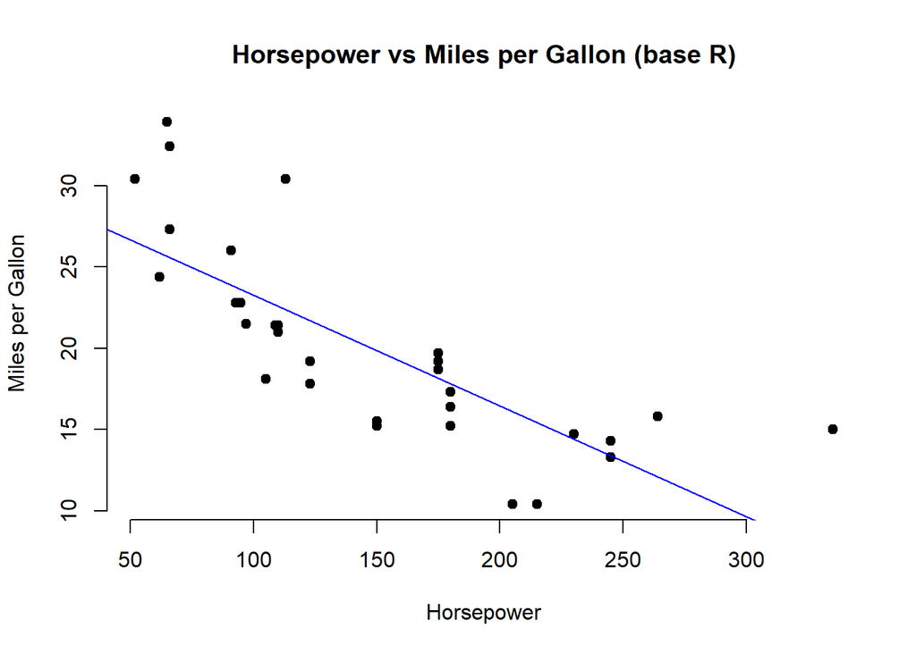

```r
x = mtcars$hp
y = mtcars$mpg
plot(x, y, main = "Horsepower vs Miles per Gallon (base R)",
     xlab = "Horsepower", ylab = "Miles per Gallon",
     pch = 19, frame = FALSE)
abline(lm(y ~ x, data = mtcars), col = "blue")
```

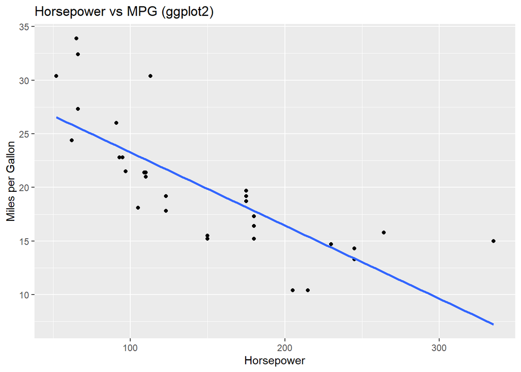

```r
library(ggplot2)
ggplot(data = mtcars, mapping = aes(x=hp, y=mpg)) +
  geom_point() +
  xlab("Horsepower") +
  ylab("Miles per Gallon") +
  geom_smooth(method=lm,se=FALSE)+
  ggtitle("Horsepower vs MPG (ggplot2)")
```

There is a negative relationship between the horsepower and miles per gallon. The higher the horsepower of the car-the more fuel it consumes per gallon, leading to the lower the mile per gallon.

## Problem 3

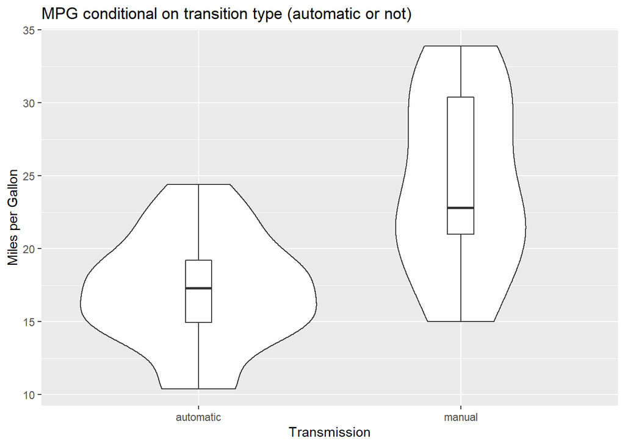

```r
mtcars<- within(mtcars, {
  am.cat <- NA # need to initialize variable
  am.cat[am == 0] <- "automatic"
  am.cat[am == 1] <- "manual"
   } )
ggplot(data = mtcars, mapping = aes(x=am.cat, y=mpg)) +
  geom_violin()+
  geom_boxplot(width=0.1)+
  xlab("Transmission") +
  ylab("Miles per Gallon") +
  ggtitle("MPG conditional on transition type (automatic or not)")
```

For cars is automatic transmission, we can observe a clearly lower MPG, which centered at 17.5 mpg, maximum around 24 mpg and minimum around 10 mpg; for cars is manual transmission, we can observe a generally higher mpg, which centered around 22.5 mpg, maximum around 33 mpg, minimum around 15 mpg.

## Problem 4

### Dodged Barchart

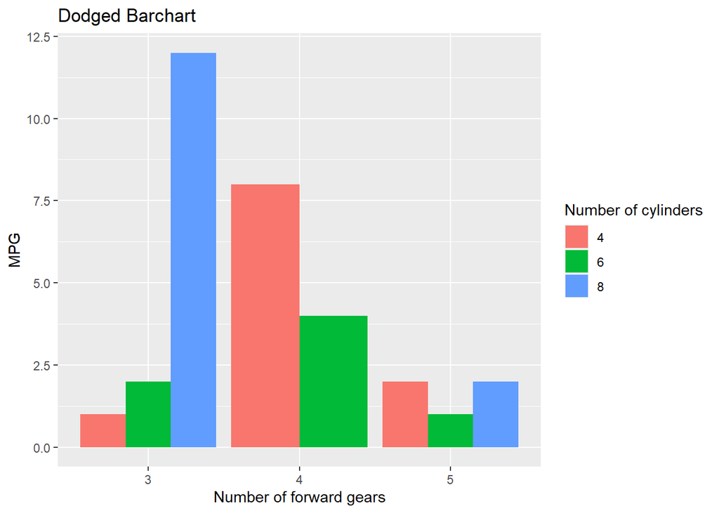

```r
mtcars$gear.factor<-factor(mtcars$gear)
mtcars$cyl.factor<-factor(mtcars$cyl)
ggplot(data = mtcars, mapping = aes(x = gear.factor, fill = cyl.factor)) +
  geom_bar(position = "dodge") +
  xlab("Number of forward gears") +
  ylab("MPG") +
  ggtitle("Dodged Barchart") +
  guides(fill = guide_legend(title = "Number of cylinders"))
```

### Stacked Barchart

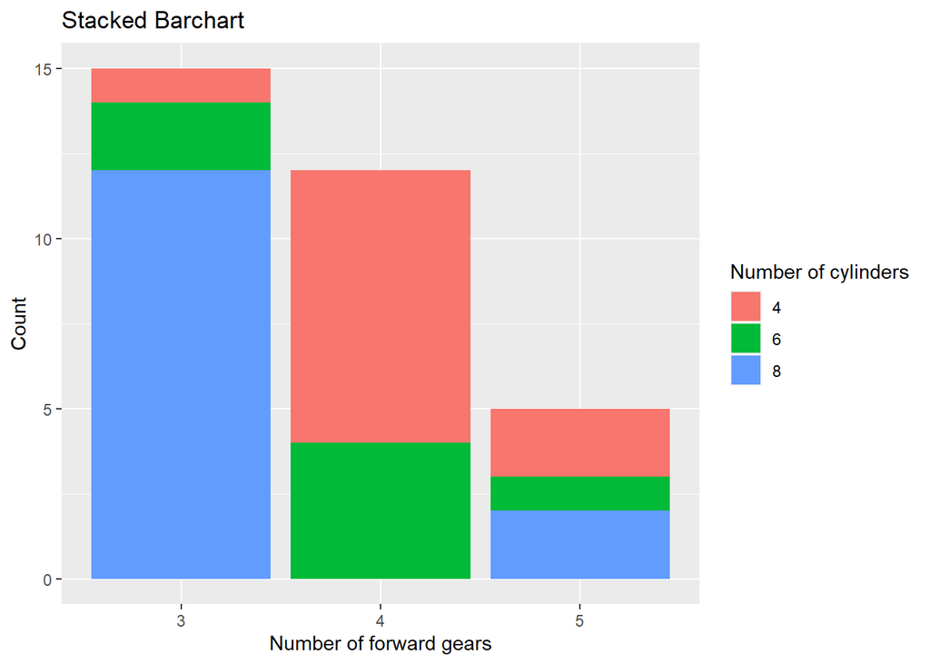

```r
ggplot(data = mtcars, mapping = aes(x = gear.factor, fill = cyl.factor)) +
  geom_bar() +
  xlab("Number of forward gears") +
  ylab("Count") +
  ggtitle("Stacked Barchart") +
  guides(fill = guide_legend(title = "Number of cylinders"))
```

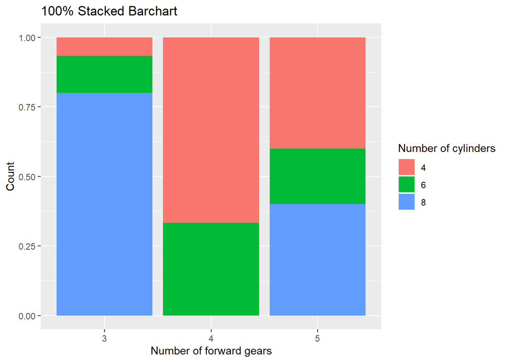

```r
ggplot(data = mtcars, mapping = aes(x = gear.factor, fill = cyl.factor)) +
  geom_bar(position = "fill") +
  xlab("Number of forward gears") +
  ylab("Count") +
  ggtitle("100% Stacked Barchart") +
  guides(fill = guide_legend(title = "Number of cylinders"))
```

## Problem 5

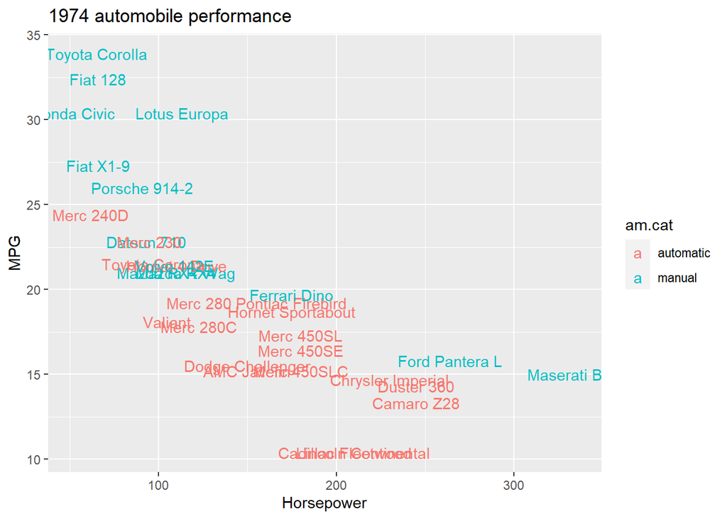

```r
mtcars$model<-rownames(mtcars)
ggplot(data = mtcars, mapping = aes(x = hp, y = mpg)) +
  geom_text(mapping = aes(label = model, color =am.cat)) +
  xlab("Horsepower") +
  ylab("MPG") +
  ggtitle("1974 automobile performance")
```